# Cluster CI enriched disease subclusters based on average shortest path between clusters

Stephanie Hickey

6/20/2022

## Set-up

```r
knitr::opts_chunk$set(echo = TRUE)
library(tidyverse)
library(poolr) # for stouffer's
library(parallel)
library(igraph)
library(leidenbase)
library(rrvgo)
library(pheatmap)
library(RColorBrewer)
library(viridis)
library(ggplotify)
library(patchwork)
library(gtable)
source("./src/chronic_inflammation_functions.R")
figure_path = "./results/prediction_clusters_same_graph/figures"
if(!dir.exists(figure_path)){dir.create(figure_path)}
```

## Caluclate similarity between CI-enriched clusters using [SAveRUNNER](https://bmcbioinformatics.biomedcentral.com/articles/10.1186/s12859-021-04076-w)

### Clean up saverunner results

Used SAveRUNNER to get network distances and p-values between every CI-enriched disease cluster. The distance calculation in SAveRUNNER is directional, so I combined the p-values between A-B with B-A using Stouffer’s method. Then I used the CI-enriched clusters as nodes and cluster those to find CI-signature groups.

```r
# Load saverunner results
sr = read.delim("./results/prediction_clusters_same_graph/SAveRUNNER/code/Results/network/txtFile/Drug_Disease_network_pval1.txt")

# for some reason saverunner changes the "drug" column
# which in our case is another cluster column
# to lower. Change the "disease" col to match

sr$disease = tolower(sr$disease)

# rename drug and disease col
sr =
  sr %>%
  dplyr::rename(Cluster1 = disease,
                Cluster2 = drug)

# combine FDR

sr_stouffers = function(row){

  print(row)
  clust1 = sr$Cluster1[row]
  clust2 = sr$Cluster2[row]
  p1 = sr$pval[row]
  sim1 = sr$adjusted_similarity[row]

  p2 =
    sr %>%
    filter(Cluster1 == clust2,
           Cluster2 == clust1) %>%
    pull(pval)

  sim2 =
    sr %>%
    filter(Cluster1 == clust2,
           Cluster2 == clust1) %>%
    pull(adjusted_similarity)

  if(row > 1){

    check =
      sr[1:(row-1),] %>%
      filter(Cluster1 == clust2,
      Cluster2 == clust1)

     if(nrow(check) > 0){

      combined =
        data.frame(Cluster1 = clust2,
                   Cluster2 = clust1,
                   stouffers_pval = stouffer(c(p1, p2), adjust = "none")$p,
                   mean_adjusted_similarity = mean(c(sim1, sim2)))
     } else {

       combined = data.frame(Cluster1 = clust1,
                        Cluster2 = clust2,
                        stouffers_pval = stouffer(c(p1, p2), adjust = "none")$p,
                        mean_adjusted_similarity = mean(c(sim1, sim2)))
     }

    } else {

       combined = data.frame(Cluster1 = clust1,
                        Cluster2 = clust2,
                        stouffers_pval = stouffer(c(p1, p2), adjust = "none")$p,
                        mean_adjusted_similarity = mean(c(sim1, sim2)))
    }

  return(combined)
}

rowtoget = 1:nrow(sr)

sr_combine_list = mclapply(rowtoget,
                           sr_stouffers,
                           mc.cores = detectCores() -1)

sr_combine = do.call(rbind, sr_combine_list)
sr_combine = dplyr::distinct(sr_combine)

# add gene plexus cv to plot
# only include traits with at least 15 seed genes
# remove collitis

load("./results/GenePlexus_parameter_checks/Geneplexus_summary_new_networks.Rdata")

cv_df =
  summary_df %>%
  filter(Network == "ConsensusPathDB") %>%
  dplyr::select(Disease,
         nSeeds,
         CVscore)

keep_disease =
  cv_df %>%
  filter(CVscore >= 1,
         nSeeds >= 15,
         !Disease == "Colitis") %>%
  pull(Disease)

sr_combine$Disease1 = gsub('_[^_]*$', '', sr_combine$Cluster1)
sr_combine$Disease2 = gsub('_[^_]*$', '', sr_combine$Cluster2)

sr_combine =
  sr_combine %>%
  filter(Disease1 %in% tolower(keep_disease),
         Disease2 %in% tolower(keep_disease))

# adjust across the whole thing for multiple comparisons
sr_combine$FDR = p.adjust(sr_combine$stouffers_pval, method = "BH")
```

- Total edges : 1275
- edges FDR <= .05 : 772
- edges FDR <= .01 : 681

### Make graph and cluster

Make an igraph object with edges between pairs with `FDR =< .01` and weight `mean_adjusted_similarity`

```r
edges =
  sr_combine %>%
  filter(FDR <= .01,
         !Cluster1 == Cluster2) %>%
  dplyr::select(Cluster1,
         Cluster2,
         mean_adjusted_similarity)

g = graph_from_edgelist(as.matrix(edges[c(1,2)]))
E(g)$weight = edges$mean_adjusted_similarity
```

Cluster and tally the number of clusters nodes from each disease belong to

```r
clusters = leiden_find_partition(g,
                                 partition_type = "ModularityVertexPartition",
                                 resolution_parameter = .01,
                                 seed = 1,
                                 edge_weights = E(g)$weight,
                                 num_iter = 100)

cluster_df = data.frame(DiseaseClusterNode = as_ids(V(g)),
                        Cluster = clusters$membership)

cluster_df$Disease = gsub('_[^_]*$', '', cluster_df$DiseaseClusterNode)

disease_tally =
  cluster_df %>%
  group_by(Disease, Cluster) %>%
  tally() %>%
  pivot_wider(id_cols = Disease,
              names_from = Cluster,
              values_from = n,
              values_fill = 0)

knitr::kable(disease_tally)
```

| Disease | 2 | 1 | 3 |
| --- | --- | --- | --- |
| alzheimers_disease | 1 | 0 | 0 |
| atherosclerosis | 1 | 1 | 1 |
| behcet_syndrome | 0 | 1 | 0 |
| celiac_disease | 0 | 0 | 1 |
| chronic_obstructive_airway_disease | 1 | 1 | 1 |
| coronary_arteriosclerosis | 1 | 0 | 1 |
| crohn_disease | 1 | 2 | 0 |
| diabetes_mellitus_insulindependent | 1 | 2 | 0 |
| endometriosis | 0 | 0 | 1 |
| fatty_liver | 1 | 0 | 0 |
| kidney_failure_chronic | 1 | 0 | 0 |
| lupus_erythematosus_systemic | 1 | 1 | 0 |
| malignant_mesothelioma | 1 | 0 | 1 |
| malignant_neoplasm_of_kidney | 0 | 1 | 0 |
| malignant_neoplasm_of_lung | 0 | 1 | 0 |
| malignant_neoplasm_of_pancreas | 0 | 0 | 1 |
| malignant_tumor_of_colon | 0 | 0 | 1 |
| multiple_sclerosis | 1 | 2 | 0 |
| myocardial_infarction | 1 | 0 | 0 |
| myocardial_ischemia | 1 | 1 | 1 |
| nonalcoholic_fatty_liver_disease | 1 | 1 | 0 |
| psoriasis | 1 | 1 | 0 |
| pulmonary_emphysema | 1 | 1 | 0 |
| rheumatoid_arthritis | 1 | 2 | 1 |
| small_cell_carcinoma_of_lung | 0 | 1 | 0 |
| squamous_cell_carcinoma_of_lung | 0 | 1 | 0 |
| ulcerative_colitis | 1 | 2 | 0 |

No disease with more than one node has all nodes in one cluster, suggesting that the genes within the disease cluster nodes are related to inflammatory processes that are not disease specific.

Are autoimmune diseases clustered?

```r
# add TraitType
# get complex vs ai lables
c_v_ai = read.csv("./data/complex_ai.csv", header = F)

# change disease to match file names
c_v_ai$Disease = gsub(" ", "_", c_v_ai$V1)
c_v_ai$Disease = gsub("([_])|[[:punct:]]", "\\1", c_v_ai$Disease)
c_v_ai$Disease = gsub("_[^_]*$", "", c_v_ai$Disease)

ai =
  c_v_ai %>%
  filter(V2 == "autoimmune") %>%
  pull(Disease)

complex =
  c_v_ai %>%
  filter(V2 == "complex") %>%
  pull(Disease)

cluster_df =
  cluster_df %>%
  mutate(TraitType =
           case_when(Disease %in% tolower(ai) ~ "Autoimmune Disease",
                     Disease %in% tolower(complex) ~ "Complex Disease",
                     !Disease %in% c(tolower(ai), tolower(complex)) ~ "Non-disease Trait"))

disease_tally =
  cluster_df %>%
  group_by(TraitType, Cluster) %>%
  tally() %>%
  pivot_wider(id_cols = TraitType,
              names_from = Cluster,
              values_from = n,
              values_fill = 0)

knitr::kable(disease_tally)
```

| TraitType | 1 | 2 | 3 |
| --- | --- | --- | --- |
| Autoimmune Disease | 13 | 7 | 2 |
| Complex Disease | 9 | 11 | 8 |

More autoimmune disease nodes are in cluster 1 than any other cluster. Is it significant?

```r
 fisher_enrich = function(trait_type, cluster){

   cluster_trait =
     cluster_df %>%
     filter(TraitType == trait_type,
            Cluster == cluster) %>%
     nrow()

   cluster_not_trait =
     cluster_df %>%
     filter(!TraitType == trait_type,
            Cluster == cluster) %>%
     nrow()

   not_cluster_trait =
     cluster_df %>%
     filter(TraitType == trait_type,
            !Cluster == cluster) %>%
     nrow()

   neither =
     cluster_df %>%
     filter(!TraitType == trait_type,
            !Cluster == cluster) %>%
     nrow()

   fish = fisher.test(matrix(c(cluster_trait,
                               cluster_not_trait,
                               not_cluster_trait,
                               neither), 2,2),
                      alternative = "greater")$p.value
   return(fish)
 }

trait_vec = {}
cluster_vec = {}
pval_vec = {}

for(i in 1:3){
  for(t in c("Autoimmune Disease", "Complex Disease")){

    trait_vec = c(trait_vec, t)
    cluster_vec = c(cluster_vec, i)
    fish = fisher_enrich(t, i)
    pval_vec = c(pval_vec, fish)

  }
}

fish_df = data.frame(TriatType = trait_vec,
                     Cluster = cluster_vec,
                     pval = pval_vec)

knitr::kable(fish_df)
```

| TriatType | Cluster | pval |
| --- | --- | --- |
| Autoimmune Disease | 1 | 0.0525330 |
| Complex Disease | 1 | 0.9861784 |
| Autoimmune Disease | 2 | 0.7997906 |
| Complex Disease | 2 | 0.4030669 |
| Autoimmune Disease | 3 | 0.9839301 |
| Complex Disease | 3 | 0.0859641 |

No enrichment for AI or complex diseases in any group.

Are similar complex diseases in the same group?

```r
cluster_df$Cluster = paste0("Group", cluster_df$Cluster)

cardio = c("coronary_arteriosclerosis",
           "myocardial_infarction",
           "myocardial_ischemia",
           "atherosclerosis")

lung = c("chronic_obstructive_airway_disease",
         "pulmonary_emphysema")

heptaorenal = c("fatty_liver",
                "kidney_failure_chronic",
                "nonalcoholic_fatty_liver_disease")

cancer = c("malignant_mesothelioma",
           "malignant_neoplasm_of_pancreas",
           "malignant_tumor_of_colon",
           "malignant_neoplasm_of_kidney",
           "malignant_neoplasm_of_lung",
           "small_cell_carcinoma_of_lung",
           "squamous_cell_carcinoma_of_lung")

all = c(tolower(ai), cardio, lung, heptaorenal, cancer)

cluster_df =
  cluster_df %>%
  mutate(TraitTypeFine =
           case_when(Disease %in% tolower(ai) ~ "Autoimmune Disease",
                     Disease %in% cardio ~ "Cardiovascular",
                     Disease %in% lung ~ "Pulminary",
                     Disease %in% heptaorenal ~ "Hepatorenal",
                     Disease %in% cancer ~ "Cancer",
                     !Disease %in% all ~ "Other"))

disease_tally =
  cluster_df %>%
  group_by(TraitTypeFine, Cluster) %>%
  tally() %>%
  pivot_wider(id_cols = TraitTypeFine,
              names_from = Cluster,
              values_from = n,
              values_fill = 0)

knitr::kable(disease_tally)
```

| TraitTypeFine | Group1 | Group2 | Group3 |
| --- | --- | --- | --- |
| Autoimmune Disease | 13 | 7 | 2 |
| Cancer | 4 | 1 | 3 |
| Cardiovascular | 2 | 4 | 3 |
| Hepatorenal | 1 | 3 | 0 |
| Other | 0 | 1 | 1 |
| Pulminary | 2 | 2 | 1 |

### Supplemental Table S7: CI-signature group assignments

```r
S7 =
  cluster_df %>%
  dplyr::rename(Cluster = DiseaseClusterNode,
                CI_SignatureGroup = Cluster)

write.csv(S7,
          file = paste0(figure_path, "/TableS7_CI_signature_groups.csv"),
          row.names = FALSE)
```

### Figure 3a

Plot CI-enriched clusters per CI-signature group by disease type

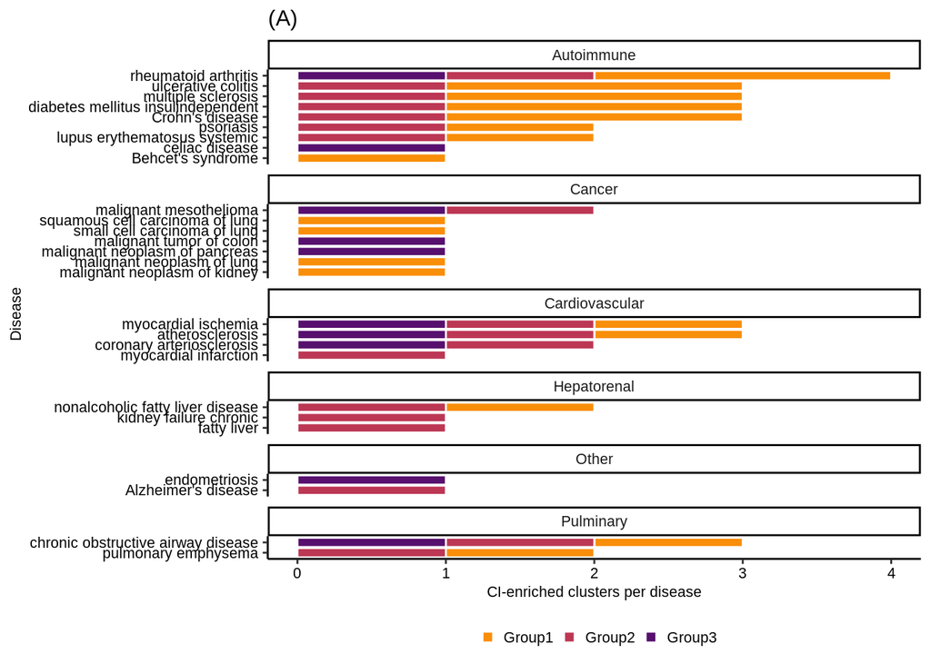

```r
cluster_df$DiseaseNiceNames = gsub("_", " ", cluster_df$Disease)
cluster_df$DiseaseNiceNames = gsub("alzheimers disease", "Alzheimer's disease", cluster_df$DiseaseNiceNames)
cluster_df$DiseaseNiceNames = gsub("behcet", "Behcet's", cluster_df$DiseaseNiceNames)
cluster_df$DiseaseNiceNames = gsub("crohn", "Crohn's", cluster_df$DiseaseNiceNames)

n_nodes_per_disease =
  cluster_df %>%
  group_by(Disease,
           TraitTypeFine) %>%
  tally(name="nNodes") %>%
  arrange(nNodes) %>%
  ungroup() %>%
  group_by(TraitTypeFine) %>%
  mutate(Order = row_number())

n_groups_per_disease =
  cluster_df %>%
  group_by(Disease,
           Cluster,
           TraitTypeFine,
           DiseaseNiceNames) %>%
  tally(name="Count")

for_plot = left_join(n_groups_per_disease, n_nodes_per_disease)
for_plot$TraitTypeFine = gsub("Autoimmune Disease",
                              "Autoimmune",
                              for_plot$TraitTypeFine)

p2 =
for_plot %>%
  ggplot(aes(y = fct_reorder(DiseaseNiceNames, Order),
             x = Count,
             fill = Cluster)) +
  geom_bar(stat = "identity", color = "white") +
  scale_fill_manual(values = c("#f98e09", "#bc3754", "#57106e")) +
  theme_classic() +
  theme(legend.position="bottom") +
  theme(legend.title = element_blank()) +
  theme(axis.text=element_text(colour="black")) +
  ylab("Disease") +
  xlab("CI-enriched clusters per disease") +
  labs(fill = "Group", title = "(A)") +
  theme(text = element_text(size = 10)) +
  theme(legend.key.size = unit(.1, 'in')) +
  theme(strip.text = element_text(size = 8)) +
  theme(axis.title = element_text(size = 8)) +
  #geom_text(aes(label = Count),
            #position = position_stack(vjust = 0.5),
            #colour = "white") +
  ggforce::facet_col(vars(TraitTypeFine), scales = "free_y", space = "free")


ggsave(p2, file = paste0(figure_path, "/groups_per_disease_cluster.png"),
       width =  7,
       height = 9)

p2
```

### Supplemental Table S8: CI-signature group enriched GOBPs

Get union of genes belonging to each node within each group. Pull the genes unique to each group and test for GOBP enrichment.

```r
clust_assign = read.csv("./results/prediction_clusters_same_graph/chronic_inflammation_gene_shot_pubs_greater10--predictedWith--ConsensusPathDB--clusteredOn--ConsensusPathDB_relevant_gene_cluster_assigments.csv", row.names = 1)

clust_assign$Cluster = tolower(clust_assign$Cluster)

node_genes =
  clust_assign %>%
  filter(Cluster %in% cluster_df$DiseaseClusterNode)

background = read.csv("./data/ConsensusPathDB/ConsensusPathDB_genes.csv")
background = background$Gene

GOBPlist = list()

for(g in unique(cluster_df$Cluster)){

  print(g)
  node_oi =
    cluster_df %>%
    filter(Cluster == g) %>%
    pull(DiseaseClusterNode)

  goi =
    node_genes %>%
    filter(Cluster %in% node_oi) %>%
    pull(Gene) %>%
    unique()

  not_goi =
    node_genes %>%
    filter(!Cluster %in% node_oi) %>%
    pull(Gene) %>%
    unique()

  goi = goi[!goi %in% not_goi]

  GOBPlist[[g]] = findEnrichedGOBP(goi,
                                  background,
                                  "org.Hs.eg.db",
                                  "entrez",
                                  min_size = 5,
                                  max_size = 100)

  GOBPlist[[g]]$Cluster = g
}
```

```
## [1] "Group2"
## [1] "Group1"
## [1] "Group3"
```

```r
unloadNamespace("package:org.Hs.eg.db")

gobp = do.call(rbind, GOBPlist)
```

Save table S8

```r
S8 =
  gobp %>%
  dplyr::rename(CI_SignatureGroup = Cluster) %>%
  dplyr::select(CI_SignatureGroup, everything())

write.csv(S8, file = paste0(figure_path, "/TableS8_CI_signature_groups_gobp_results.csv"), row.names = F)
```

Top GOBPs

```r
topBP =
  gobp %>%
  filter(FDR < .01) %>%
  group_by(Cluster) %>%
  dplyr::select(-OverlappingGenes) %>%
  top_n(-10, FDR)

knitr::kable(topBP)
```

| GO.ID | Term | Annotated | Significant | Expected | pval | FDR | Cluster |
| --- | --- | --- | --- | --- | --- | --- | --- |
| GO:0042531 | positive regulation of tyrosine phosphorylation of STAT protein | 66 | 12 | 0.40 | 4.4e-15 | 0.00e+00 | Group2 |
| GO:0045840 | positive regulation of mitotic nuclear division | 43 | 9 | 0.26 | 3.5e-12 | 0.00e+00 | Group2 |
| GO:0014068 | positive regulation of phosphatidylinositol 3-kinase signaling | 87 | 10 | 0.53 | 1.1e-10 | 3.00e-07 | Group2 |
| GO:0051781 | positive regulation of cell division | 81 | 9 | 0.49 | 1.3e-09 | 2.40e-06 | Group2 |
| GO:0042102 | positive regulation of T cell proliferation | 96 | 15 | 0.58 | 1.1e-08 | 1.47e-05 | Group2 |
| GO:0010862 | positive regulation of pathway-restricted SMAD protein phosphorylation | 47 | 7 | 0.28 | 1.2e-08 | 1.47e-05 | Group2 |
| GO:0038114 | interleukin-21-mediated signaling pathway | 8 | 4 | 0.05 | 8.6e-08 | 7.93e-05 | Group2 |
| GO:0033084 | regulation of immature T cell proliferation in thymus | 8 | 4 | 0.05 | 8.6e-08 | 7.93e-05 | Group2 |
| GO:0010718 | positive regulation of epithelial to mesenchymal transition | 48 | 9 | 0.29 | 1.1e-07 | 9.01e-05 | Group2 |
| GO:0030890 | positive regulation of B cell proliferation | 40 | 6 | 0.24 | 1.3e-07 | 9.59e-05 | Group2 |
| GO:0032735 | positive regulation of interleukin-12 production | 40 | 15 | 0.58 | 5.2e-18 | 0.00e+00 | Group1 |
| GO:0002755 | MyD88-dependent toll-like receptor signaling pathway | 34 | 14 | 0.50 | 1.4e-17 | 0.00e+00 | Group1 |
| GO:0031663 | lipopolysaccharide-mediated signaling pathway | 55 | 19 | 0.80 | 3.1e-16 | 0.00e+00 | Group1 |
| GO:0032729 | positive regulation of interferon-gamma production | 63 | 16 | 0.92 | 4.9e-16 | 0.00e+00 | Group1 |
| GO:0032757 | positive regulation of interleukin-8 production | 56 | 15 | 0.82 | 1.7e-15 | 0.00e+00 | Group1 |
| GO:0032760 | positive regulation of tumor necrosis factor production | 81 | 16 | 1.18 | 3.6e-14 | 0.00e+00 | Group1 |
| GO:0038110 | interleukin-2-mediated signaling pathway | 12 | 8 | 0.17 | 8.5e-13 | 0.00e+00 | Group1 |
| GO:0071260 | cellular response to mechanical stimulus | 73 | 14 | 1.06 | 2.3e-12 | 0.00e+00 | Group1 |
| GO:1901224 | positive regulation of NIK/NF-kappaB signaling | 65 | 13 | 0.95 | 8.0e-12 | 0.00e+00 | Group1 |
| GO:0034142 | toll-like receptor 4 signaling pathway | 37 | 13 | 0.54 | 3.3e-11 | 0.00e+00 | Group1 |
| GO:0002548 | monocyte chemotaxis | 67 | 20 | 0.29 | 9.5e-25 | 0.00e+00 | Group3 |
| GO:0048245 | eosinophil chemotaxis | 19 | 9 | 0.08 | 2.6e-17 | 0.00e+00 | Group3 |
| GO:0061844 | antimicrobial humoral immune response mediated by antimicrobial peptide | 75 | 12 | 0.32 | 3.0e-16 | 0.00e+00 | Group3 |
| GO:2000503 | positive regulation of natural killer cell chemotaxis | 6 | 6 | 0.03 | 5.0e-15 | 0.00e+00 | Group3 |
| GO:0010820 | positive regulation of T cell chemotaxis | 15 | 7 | 0.06 | 1.2e-13 | 0.00e+00 | Group3 |
| GO:0048247 | lymphocyte chemotaxis | 61 | 21 | 0.26 | 7.9e-11 | 1.00e-07 | Group3 |
| GO:0090026 | positive regulation of monocyte chemotaxis | 20 | 6 | 0.09 | 1.9e-10 | 2.00e-07 | Group3 |
| GO:1904995 | negative regulation of leukocyte adhesion to vascular endothelial cell | 5 | 4 | 0.02 | 1.6e-09 | 1.50e-06 | Group3 |
| GO:0072679 | thymocyte migration | 6 | 4 | 0.03 | 4.6e-09 | 3.80e-06 | Group3 |
| GO:0002692 | negative regulation of cellular extravasation | 7 | 4 | 0.03 | 1.1e-08 | 7.40e-06 | Group3 |
| GO:2000669 | negative regulation of dendritic cell apoptotic process | 7 | 4 | 0.03 | 1.1e-08 | 7.40e-06 | Group3 |

### Figure 3b: top 10 GOBP terms heat map

```r
gobp$log10FDR = -log10(gobp$FDR)

top_g1 =
  topBP %>%
  filter(Cluster == "Group1") %>%
  pull(Term)

gobp_top1 =
  gobp %>%
  filter(Term %in% top_g1) %>%
  dplyr::select(Term,
                log10FDR,
                Cluster) %>%
  pivot_wider(id_cols=Term,
              names_from=Cluster,
              values_from=log10FDR) %>%
  arrange(desc(Group1)) %>%
  dplyr::select(Term, Group1, Group2, Group3)

top_g2 =
  topBP %>%
  filter(Cluster == "Group2") %>%
  pull(Term)

gobp_top2 =
  gobp %>%
  filter(Term %in% top_g2) %>%
  dplyr::select(Term,
                log10FDR,
                Cluster) %>%
  pivot_wider(id_cols=Term,
              names_from=Cluster,
              values_from=log10FDR) %>%
  arrange(desc(Group2)) %>%
  dplyr::select(Term, Group1, Group2, Group3)

top_g3 =
  topBP %>%
  filter(Cluster == "Group3") %>%
  pull(Term)

gobp_top3 =
  gobp %>%
  filter(Term %in% top_g3) %>%
  dplyr::select(Term,
                log10FDR,
                Cluster) %>%
  pivot_wider(id_cols=Term,
              names_from=Cluster,
              values_from=log10FDR) %>%
  arrange(desc(Group3)) %>%
  dplyr::select(Term, Group1, Group2, Group3)

gobp_top = as.data.frame(rbind(gobp_top1,gobp_top2,gobp_top3))

rownames(gobp_top) = gobp_top$Term
gobp_top$Term = NULL
gobp_top = as.matrix(gobp_top)

stars = gobp_top
stars[stars < -log10(.01)] = ""
stars[stars != ""] = "*"

# for annotation
top_g1 = as.data.frame(top_g1)
colnames(top_g1) = "Term"
top_g1$Top.Terms.For = "Group1"

top_g2 = as.data.frame(top_g2)
colnames(top_g2) = "Term"
top_g2$Top.Terms.For = "Group2"

top_g3 = as.data.frame(top_g3)
colnames(top_g3) = "Term"
top_g3$Top.Terms.For = "Group3"

anno = rbind(top_g1, top_g2, top_g3)
rownames(anno) = anno$Term
anno$Term = NULL

paletteLength <- 100
myColor = colorRampPalette(c("#fcffa4", "#f98e09", "#bc3754"))((100))

ann_colors = list(
    Top.Terms.For = c(Group1 = "#f98e09",
                      Group2 = "#bc3754",
                      Group3 = "#57106e")
)
```

Make plot without legend and add it back later with affinity

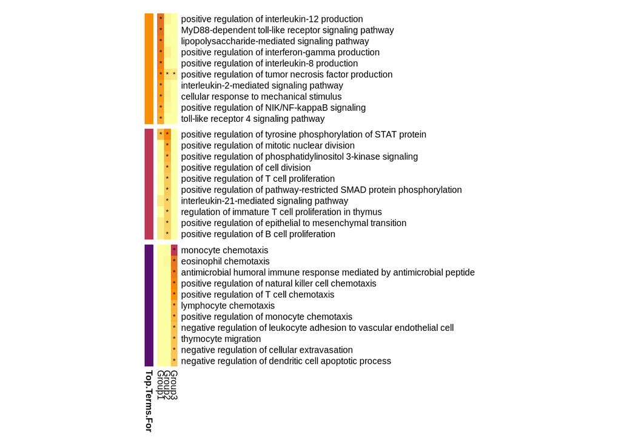

```r
pheat.map.clust =
pheatmap(gobp_top,
           color = myColor,
           border_color = NA,
           cluster_rows = FALSE,
           cluster_cols = FALSE,
           show_colnames = TRUE,
           show_rownames = TRUE,
           gaps_row = c(10, 20),
           display_numbers = stars,
           annotation_row = anno,
           annotation_colors = ann_colors,
           annotation_legend = FALSE,
           legend = FALSE,
           number_color = "black",
           cellwidth = 5.5,
           cellheight = 9,
           fontsize = 7.25)
```

version with legend

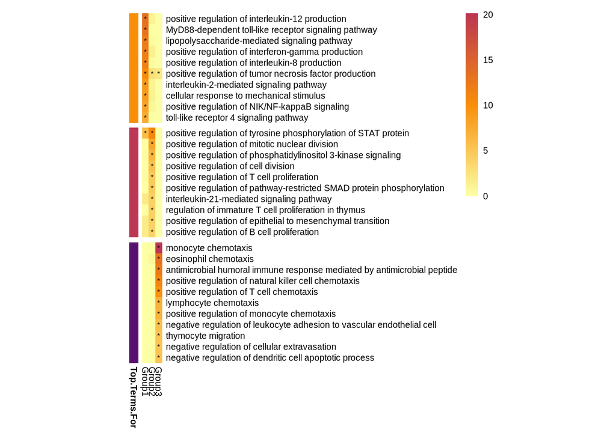

```r
pheat.map.leg =
pheatmap(gobp_top,
           color = myColor,
           border_color = NA,
           cluster_rows = FALSE,
           cluster_cols = FALSE,
           show_colnames = TRUE,
           show_rownames = TRUE,
           gaps_row = c(10, 20),
           display_numbers = stars,
           annotation_row = anno,
           annotation_colors = ann_colors,
           annotation_legend = FALSE,
           legend = TRUE,
           number_color = "black",
           cellwidth = 5.5,
           cellheight = 9,
           fontsize = 7.25)
```

```r
#place legend later in Affinity
ggsave(pheat.map.leg, file = paste0(figure_path, "/gopb_heatmap_legend.png"))
```

## Fig3 composite

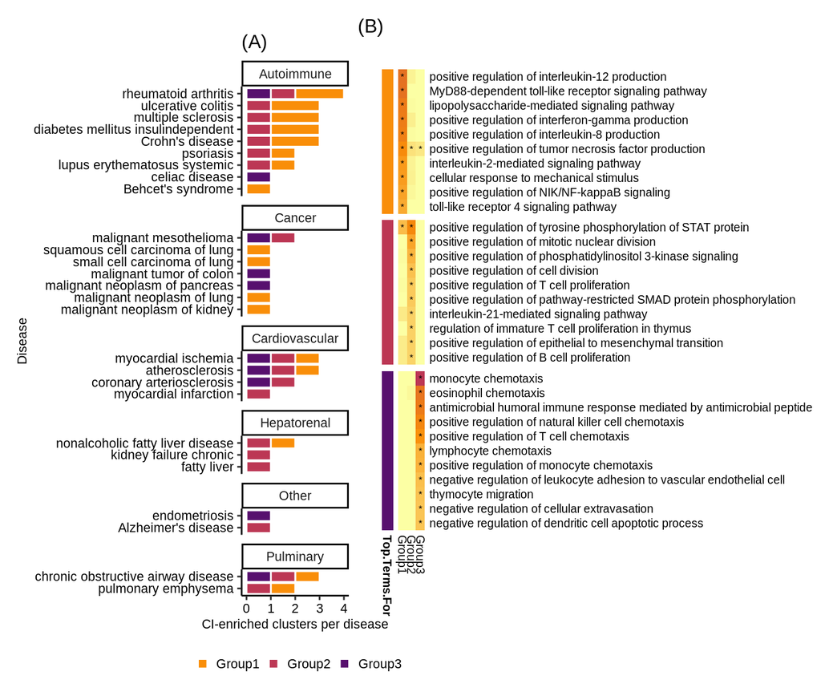

```r
gg_pheatmap =
  as.ggplot(pheat.map.clust) +
  labs(tag = "(B)") +
  theme(text = element_text(size = 10))

fig3 = (p2 | gg_pheatmap) + plot_layout(width = c(1,4))
ggsave(fig3,
       file = paste0(figure_path, "/Fig3.png"),
       width = 180,
       height = 153,
       units = "mm")

fig3
```

Fix the pannel labels in Affinity